```python
import pandas as pd
```

```python
data=pd.read_csv('global7.csv')
data
```

|  | Column1 | Unnamed: 0 | Row ID | Order ID | Order Date | Day | Ship Date | Ship Mode | Customer ID | Customer Name | ... | Sub-Category | Product Name | Quantity | Discount | Profit | Shipping Cost | Order Priority | sales in rupees | into qua | last sale |
| --- | --- | --- | --- | --- | --- | --- | --- | --- | --- | --- | --- | --- | --- | --- | --- | --- | --- | --- | --- | --- | --- |
| 0 | 0 | 0 | 40098 | CA-2020-AB10015140-41954 | 11-11-2020 | Tuesday | 13-11-2020 | NaN | AB-100151402 | Aaron Bergman | ... | Phones | Samsung Convoy 3 | 2 | 0.00% | 62.15 | 40.770 | High | #REF! | #REF! | #REF! |
| 1 | 1 | 1 | 26341 | IN-2020-JR162107-41675 | 05-02-2020 | Wednesday | 07-02-2020 | Second Class | JR-162107 | Justin Ritter | ... | Chairs | Novimex Executive Leather Armchair, Black | 9 | 10.00% | -288.77 | 923.630 | Critical | #REF! | #REF! | #REF! |
| 2 | 2 | 2 | 25330 | IN-2020-CR127307-41929 | 17-10-2020 | Friday | 18-10-2020 | First Class | CR-127307 | Craig Reiter | ... | Phones | Nokia Smart Phone, with Caller ID | 9 | 10.00% | 919.97 | 915.490 | Medium | #REF! | #REF! | #REF! |
| 3 | 3 | 3 | 13524 | ES-2020-KM1637548-41667 | 28-01-2020 | Tuesday | 30-01-2020 | First Class | KM-1637548 | Katherine Murray | ... | Phones | Motorola Smart Phone, Cordless | 5 | 10.00% | -96.54 | 910.160 | Medium | #REF! | #REF! | #REF! |
| 4 | 4 | 4 | 47221 | SG-2020-RH9495111-41948 | 05-11-2020 | Wednesday | 06-11-2020 | Same Day | RH-9495111 | Rick Hansen | ... | Copiers | Sharp Wireless Fax, High-Speed | 8 | 0.00% | 311.52 | 903.040 | Critical | #REF! | #REF! | #REF! |
| ... | ... | ... | ... | ... | ... | ... | ... | ... | ... | ... | ... | ... | ... | ... | ... | ... | ... | ... | ... | ... | ... |
| 51285 | 51285 | 51285 | 29002 | IN-2019-KE1642066-42174 | 19-06-2019 | Friday | 19-06-2019 | Same Day | KE-1642066 | Katrina Edelman | ... | Fasteners | Advantus Thumb Tacks, 12 Pack | 5 | 0.00% | 4.5 | 1.010 | Medium | NaN | NaN | NaN |
| 51286 | 51286 | 51286 | 34337 | US-2020-ZD21925140-41765 | 06-05-2020 | Tuesday | 10-05-2020 | Standard Class | ZD-219251408 | Zuschuss Donatelli | ... | Furnishings | Eldon Image Series Desk Accessories, Burgundy | 5 | 20.00% | 3.34 | 1.930 | High | NaN | NaN | NaN |
| 51287 | 51287 | 51287 | 31315 | CA-2021-ZD21925140-41147 | 26-08-2021 | Sunday | 31-08-2021 | Second Class | ZD-219251404 | Zuschuss Donatelli | ... | Art | Newell 341 | 2 | 0.00% | 2.48 | 1.580 | High | NaN | NaN | NaN |
| 51288 | 51288 | 51288 | 9596 | MX-2022-RB1979518-41322 | 17-02-2022 | Sunday | 21-02-2022 | NaN | RB-1979518 | Ross Baird | ... | Binders | Acco Index Tab, Economy | 2 | 0.00% | 2.4 | 1.003 | Medium | NaN | NaN | NaN |
| 51289 | 51289 | 51289 | 6147 | MX-2022-MC1810093-41416 | 22-05-2022 | Wednesday | 26-05-2022 | Second Class | MC-1810093 | Mick Crebagga | ... | Paper | Eaton Computer Printout Paper, 8.5 x 11 | 3 | 0.00% | 1.8 | 1.002 | High | NaN | NaN | NaN |

51290 rows × 29 columns

# Data Cleaning

```python
data.info()
```

```
<class 'pandas.core.frame.DataFrame'>
RangeIndex: 51290 entries, 0 to 51289
Data columns (total 29 columns):
 #   Column           Non-Null Count  Dtype
---  ------           --------------  -----
 0   Column1          51290 non-null  int64
 1   Unnamed: 0       51290 non-null  int64
 2   Row ID           51290 non-null  int64
 3   Order ID         51290 non-null  object
 4   Order Date       51290 non-null  object
 5   Day              51290 non-null  object
 6   Ship Date        51290 non-null  object
 7   Ship Mode        51035 non-null  object
 8   Customer ID      51290 non-null  object
 9   Customer Name    51290 non-null  object
```

[output cut: 21 more lines]

```python
data.drop(['Column1','Unnamed: 0','sales in rupees','into qua','last sale'],axis=1,inplace=True)
```

```python
data.drop(['Discount'],axis=1,inplace=True)
```

```python
data.dtypes
```

```
Row ID              int64
Order ID           object
Order Date         object
Day                object
Ship Date          object
Ship Mode          object
Customer ID        object
Customer Name      object
Segment            object
Postal Code       float64
City               object
State              object
Country            object
Region             object
Market             object
Product ID         object
Category           object
Sub-Category       object
Product Name       object
Quantity            int64
 Profit            object
Shipping Cost     float64
Order Priority     object
dtype: object
```

```python
data['Order Date'] = pd.to_datetime(data['Order Date'], format='%d-%m-%Y', errors='coerce')
```

```python
data['Ship Date']=pd.to_datetime(data['Ship Date'],format='%d-%m-%Y',errors='coerce')
```

```python
data.rename(columns={' Profit ': 'Profit'}, inplace=True)
```

```python
data['Profit']=pd.to_numeric(data['Profit'],errors='coerce')
```

```python
data.isnull().sum()
```

```
Row ID                0
Order ID              0
Order Date           53
Day                   0
Ship Date             6
Ship Mode           255
Customer ID           0
Customer Name         0
Segment               0
Postal Code       41296
City                  0
State                 0
Country               0
Region                0
Market                0
Product ID            0
Category              0
Sub-Category          0
Product Name          0
Quantity              0
Profit              225
Shipping Cost         0
Order Priority        0
dtype: int64
```

```python
ship_mode=data['Ship Mode'].mode()[0]
data['Ship Mode'].fillna(value=ship_mode,inplace=True)
```

```python
ship_mode=data['Ship Date'].mode()[0]
data['Ship Date'].fillna(value=ship_mode,inplace=True)
```

```python
ship_mode=data['Order Date'].mode()[0]
data['Order Date'].fillna(value=ship_mode,inplace=True)
```

```python
postal_code_mean=data['Postal Code'].mean()
data['Postal Code'].fillna(value=postal_code_mean,inplace=True)
```

```python
profit_mean=data['Profit'].mean()
data['Profit'].fillna(value=profit_mean,inplace=True)
```

# Summary Statistics

```python
print("Summary statistics for numerical columns:")
data.describe()
```

```
Summary statistics for numerical columns:
```

|  | Row ID | Postal Code | Quantity | Profit | Shipping Cost |
| --- | --- | --- | --- | --- | --- |
| count | 51290.000000 | 51290.000000 | 51290.000000 | 51290.000000 | 51290.000000 |
| mean | 25645.563463 | 55190.379428 | 3.476545 | 26.619011 | 26.478567 |
| std | 14806.268930 | 14153.028275 | 2.278766 | 119.626798 | 57.251373 |
| min | 1.000000 | 1040.000000 | 1.000000 | -996.780000 | 1.002000 |
| 25% | 12823.250000 | 55190.379428 | 2.000000 | 0.000000 | 2.610000 |
| 50% | 25645.500000 | 55190.379428 | 3.000000 | 9.300000 | 7.790000 |
| 75% | 38467.750000 | 55190.379428 | 5.000000 | 36.157500 | 24.450000 |
| max | 51290.000000 | 99301.000000 | 14.000000 | 999.360000 | 933.570000 |

# Count of unique values in categorical columns

```python
print("Count of unique values in categorical columns:")
for column in data.select_dtypes(include=['object']).columns:
    print(f"{column}: {data[column].nunique()} unique values")
```

```
Count of unique values in categorical columns:
Order ID: 25727 unique values
Day: 7 unique values
Ship Mode: 4 unique values
Customer ID: 17405 unique values
Customer Name: 796 unique values
Segment: 3 unique values
City: 3650 unique values
State: 1102 unique values
Country: 165 unique values
Region: 23 unique values
Market: 5 unique values
Product ID: 3788 unique values
Category: 3 unique values
Sub-Category: 17 unique values
Product Name: 3788 unique values
Order Priority: 4 unique values
```

# Total Profit and Quantity by Category

```python
print("Total Profit and Quantity by Category:")
category_group = data.groupby('Category')[['Profit', 'Quantity']].sum()
category_group
```

```
Total Profit and Quantity by Category:
```

| Category | Profit | Quantity |
| --- | --- | --- |
| Furniture | 291755.842726 | 34892 |
| Office Supplies | 492363.290640 | 108244 |
| Technology | 581169.924035 | 35176 |

# Top 10 orders by Quantity

```python
print("Top 10 orders by Quantity:")
top_quantity_orders = data.sort_values(by='Quantity', ascending=False).head(10)
top_quantity_orders
```

```
Top 10 orders by Quantity:
```

|  | Row ID | Order ID | Order Date | Day | Ship Date | Ship Mode | Customer ID | Customer Name | Segment | Postal Code | ... | Region | Market | Product ID | Category | Sub-Category | Product Name | Quantity | Profit | Shipping Cost | Order Priority |
| --- | --- | --- | --- | --- | --- | --- | --- | --- | --- | --- | --- | --- | --- | --- | --- | --- | --- | --- | --- | --- | --- |
| 7971 | 43213 | CG-2019-JR570033-42272 | 2019-09-25 | Friday | 2019-09-30 | Standard Class | JR-570033 | Jocasta Rupert | Consumer | 55190.379428 | ... | Central Africa | Africa | OFF-AR-3449 | Office Supplies | Art | BIC Canvas, Fluorescent | 14 | 269.220000 | 42.57 | Medium |
| 17405 | 19420 | IT-2019-MG18205139-42242 | 2019-08-26 | Wednesday | 2019-08-29 | Second Class | MG-18205139 | Mitch Gastineau | Corporate | 55190.379428 | ... | Northern Europe | Europe | FUR-FU-3066 | Furniture | Furnishings | Advantus Stacking Tray, Durable | 14 | -11.210000 | 15.76 | Medium |
| 40522 | 34244 | CA-2019-MP18175140-42353 | 2019-12-15 | Tuesday | 2019-12-19 | Standard Class | MP-181751404 | Mike Pelletier | Home Office | 92024.000000 | ... | Western US | USCA | OFF-BI-6387 | Office Supplies | Binders | Wilson Jones Clip & Carry Folder Binder Tool f... | 14 | 22.740000 | 5.32 | High |
| 15388 | 26869 | IN-2021-MW182357-41052 | 2021-05-23 | Wednesday | 2021-05-27 | Standard Class | MW-182357 | Mitch Willingham | Corporate | 55190.379428 | ... | Oceania | Asia Pacific | OFF-AR-3498 | Office Supplies | Art | Binney & Smith Pens, Water Color | 14 | 63.250000 | 19.02 | High |
| 33134 | 43138 | NI-2020-PR888095-41982 | 2020-12-09 | Tuesday | 2020-12-11 | First Class | PR-888095 | Patrick Ryan | Consumer | 55190.379428 | ... | Western Africa | Africa | OFF-BI-3292 | Office Supplies | Binders | Avery Hole Reinforcements, Recycled | 14 | -18.190000 | 4.22 | High |
| 13398 | 32726 | US-2022-DK12835140-41578 | 2022-10-31 | Thursday | 2022-11-04 | Second Class | DK-128351404 | Damala Kotsonis | Corporate | 93905.000000 | ... | Western US | USCA | OFF-LA-3190 | Office Supplies | Labels | Avery 4027 File Folder Labels for Dot Matrix P... | 14 | 196.610000 | 42.26 | High |
| 17675 | 47093 | AU-2019-DA34508-42355 | 2019-12-17 | Thursday | 2019-12-22 | Standard Class | DA-34508 | Dianna Arnett | Home Office | 55190.379428 | ... | Western Europe | Europe | OFF-BI-4817 | Office Supplies | Binders | Ibico Binding Machine, Economy | 14 | 64.680000 | 15.41 | Medium |
| 10107 | 19306 | ES-2022-SC20260139-41625 | 2022-12-17 | Tuesday | 2022-12-21 | Second Class | SC-20260139 | Scott Cohen | Corporate | 55190.379428 | ... | Northern Europe | Europe | OFF-BI-3714 | Office Supplies | Binders | Cardinal 3-Hole Punch, Economy | 14 | 181.440000 | 32.45 | Medium |
| 2680 | 49660 | TU-2022-TA11385134-41326 | 2022-02-21 | Thursday | 2022-02-27 | Standard Class | TA-11385134 | Tom Ashbrook | Home Office | 55190.379428 | ... | Western Asia | Asia Pacific | FUR-CH-5454 | Furniture | Chairs | Office Star Swivel Stool, Adjustable | 14 | 26.619011 | 107.91 | Low |
| 31397 | 49851 | PL-2019-BD1725103-42217 | 2019-08-01 | Saturday | 2019-08-08 | Standard Class | BD-1725103 | Bruce Degenhardt | Consumer | 55190.379428 | ... | Eastern Europe | Europe | OFF-BI-3735 | Office Supplies | Binders | Cardinal Hole Reinforcements, Economy | 14 | 30.240000 | 4.90 | Low |

10 rows × 23 columns

# Top 10 orders by Category

```python
top_profit=data.sort_values(by='Category',ascending=False).head(10)
top_profit
```

|  | Row ID | Order ID | Order Date | Day | Ship Date | Ship Mode | Customer ID | Customer Name | Segment | Postal Code | ... | Region | Market | Product ID | Category | Sub-Category | Product Name | Quantity | Profit | Shipping Cost | Order Priority |
| --- | --- | --- | --- | --- | --- | --- | --- | --- | --- | --- | --- | --- | --- | --- | --- | --- | --- | --- | --- | --- | --- |
| 0 | 40098 | CA-2020-AB10015140-41954 | 2020-11-11 | Tuesday | 2020-11-13 | Standard Class | AB-100151402 | Aaron Bergman | Consumer | 73120.000000 | ... | Central US | USCA | TEC-PH-5816 | Technology | Phones | Samsung Convoy 3 | 2 | 62.15 | 40.770 | High |
| 22567 | 12616 | IT-2022-AO1081064-41548 | 2022-10-01 | Tuesday | 2022-10-05 | Standard Class | AO-1081064 | Anthony O'Donnell | Corporate | 55190.379428 | ... | Southern Europe | Europe | TEC-PH-5252 | Technology | Phones | Motorola Headset, Full Size | 2 | -29.18 | 10.050 | Medium |
| 9981 | 14268 | ES-2021-AH1021045-41244 | 2021-12-01 | Saturday | 2021-12-02 | First Class | AH-1021045 | Alan Hwang | Consumer | 55190.379428 | ... | Western Europe | Europe | TEC-MA-5001 | Technology | Machines | Konica Calculator, Wireless | 5 | 82.48 | 32.970 | Medium |
| 9983 | 20785 | ID-2019-GM14680102-42368 | 2019-12-30 | Wednesday | 2016-01-03 | Standard Class | GM-14680102 | Greg Matthias | Consumer | 55190.379428 | ... | Southeastern Asia | Asia Pacific | TEC-CO-4771 | Technology | Copiers | HP Fax and Copier, High-Speed | 3 | -56.52 | 32.970 | High |
| 33804 | 30439 | IN-2022-EM1396092-41289 | 2022-01-15 | Tuesday | 2022-01-20 | Second Class | EM-1396092 | Eric Murdock | Consumer | 55190.379428 | ... | Oceania | Asia Pacific | TEC-MA-4193 | Technology | Machines | Epson Card Printer, Durable | 2 | 54.42 | 3.980 | Medium |
| 44273 | 34439 | CA-2019-RB19360140-42273 | 2019-09-26 | Saturday | 2019-09-28 | Second Class | RB-193601406 | Raymond Buch | Consumer | 45231.000000 | ... | Eastern US | USCA | TEC-AC-5094 | Technology | Accessories | Logitech 910-002974 M325 Wireless Mouse for We... | 5 | 35.99 | 9.660 | High |
| 44271 | 2634 | US-2020-HD1478598-41987 | 2020-12-14 | Sunday | 2020-12-20 | Standard Class | HD-1478598 | Harold Dahlen | Home Office | 55190.379428 | ... | Central America | LATAM | TEC-AC-5130 | Technology | Accessories | Logitech Numeric Keypad, Bluetooth | 2 | -1.86 | 1.741 | Medium |
| 9989 | 25461 | IN-2021-VP217307-41166 | 2021-09-14 | Friday | 2021-09-17 | Second Class | VP-217307 | Victor Preis | Home Office | 55190.379428 | ... | Oceania | Asia Pacific | TEC-AC-4155 | Technology | Accessories | Enermax Keyboard, Bluetooth | 1 | -5.86 | 32.940 | Critical |
| 9990 | 4323 | MX-2022-JF1519026-41305 | 2022-01-31 | Thursday | 2022-02-05 | Standard Class | JF-1519026 | Jamie Frazer | Consumer | 55190.379428 | ... | South America | LATAM | TEC-PH-5339 | Technology | Phones | Nokia Headset, Cordless | 3 | 71.40 | 32.938 | High |
| 33809 | 47507 | EG-2020-JS594038-41739 | 2020-04-10 | Thursday | 2020-04-14 | Second Class | JS-594038 | Joni Sundaresam | Home Office | 55190.379428 | ... | North Africa | Africa | TEC-AC-5201 | Technology | Accessories | Memorex Keyboard, Programmable | 1 | 30.57 | 3.980 | Medium |

10 rows × 23 columns

# Average Shipping Cost by Market and Region

```python
avg_shipping_cost = data.groupby(['Market', 'Region'])['Shipping Cost'].mean()
print("Average Shipping Cost by Market and Region:")
avg_shipping_cost
```

```
Average Shipping Cost by Market and Region:
```

```
Market        Region
Africa        Central Africa       25.485397
              Eastern Africa       21.006497
              North Africa         19.353967
              Southern Africa      27.377657
              Western Africa       13.245712
Asia Pacific  Central Asia          8.457189
              Eastern Asia         40.368075
              Oceania              34.643393
              Southeastern Asia    30.002826
              Southern Asia        34.285834
              Western Asia         14.131107
Europe        Eastern Europe       22.395572
              Northern Europe      29.734385
              Southern Europe      29.951003
              Western Europe       31.589521
LATAM         Caribbean            21.145193
              Central America      23.472235
              South America        22.580377
USCA          Canada               19.389661
              Central US           21.255588
              Eastern US           25.722479
              Southern US          24.910603
              Western US           24.046913
Name: Shipping Cost, dtype: float64
```

# Total Profit

```python
total_profit = data['Profit'].sum()
print("Total Profit:", total_profit)
```

```
Total Profit: 1365289.0574013512
```

# Average Shipping Cost

```python
avg_shipping_cost = data['Shipping Cost'].mean()
print("Average Shipping Cost:", avg_shipping_cost)
```

```
Average Shipping Cost: 26.478567038409036
```

# Most Common Product Category

```python
most_common_category = data['Category'].value_counts().idxmax()
print("Most Common Product Category:", most_common_category)
```

```
Most Common Product Category: Office Supplies
```

# Total Quantity Sold

```python
total_quantity_sold = data['Quantity'].sum()
print("Total Quantity Sold:", total_quantity_sold)
```

```
Total Quantity Sold: 178312
```

# Average Profit per Category

```python
avg_profit_per_category = data.groupby('Category')['Profit'].mean()
print("Average Profit per Category:\n", avg_profit_per_category)
```

```
Average Profit per Category:
 Category
Furniture          29.589842
Office Supplies    15.735987
Technology         57.308936
Name: Profit, dtype: float64
```

# highest_profit_orders

```python
highest_profit_orders=data[data['Profit']==data['Profit'].max()]
highest_profit_orders
```

|  | Row ID | Order ID | Order Date | Day | Ship Date | Ship Mode | Customer ID | Customer Name | Segment | Postal Code | ... | Region | Market | Product ID | Category | Sub-Category | Product Name | Quantity | Profit | Shipping Cost | Order Priority |
| --- | --- | --- | --- | --- | --- | --- | --- | --- | --- | --- | --- | --- | --- | --- | --- | --- | --- | --- | --- | --- | --- |
| 1110 | 6006 | MX-2021-JH1543082-40913 | 2021-01-05 | Thursday | 2021-01-09 | Standard Class | JH-1543082 | Jennifer Halladay | Consumer | 55190.379428 | ... | Central America | LATAM | OFF-AP-4742 | Office Supplies | Appliances | Hoover Stove, Black | 8 | 999.36 | 191.201 | Medium |

1 rows × 23 columns

# Selected Columns

```python
selected_columns = data[['Order ID', 'Order Date', 'Customer Name', 'Product Name', 'Quantity']]
selected_columns
```

|  | Order ID | Order Date | Customer Name | Product Name | Quantity |
| --- | --- | --- | --- | --- | --- |
| 0 | CA-2020-AB10015140-41954 | 2020-11-11 | Aaron Bergman | Samsung Convoy 3 | 2 |
| 1 | IN-2020-JR162107-41675 | 2020-02-05 | Justin Ritter | Novimex Executive Leather Armchair, Black | 9 |
| 2 | IN-2020-CR127307-41929 | 2020-10-17 | Craig Reiter | Nokia Smart Phone, with Caller ID | 9 |
| 3 | ES-2020-KM1637548-41667 | 2020-01-28 | Katherine Murray | Motorola Smart Phone, Cordless | 5 |
| 4 | SG-2020-RH9495111-41948 | 2020-11-05 | Rick Hansen | Sharp Wireless Fax, High-Speed | 8 |
| ... | ... | ... | ... | ... | ... |
| 51285 | IN-2019-KE1642066-42174 | 2019-06-19 | Katrina Edelman | Advantus Thumb Tacks, 12 Pack | 5 |
| 51286 | US-2020-ZD21925140-41765 | 2020-05-06 | Zuschuss Donatelli | Eldon Image Series Desk Accessories, Burgundy | 5 |
| 51287 | CA-2021-ZD21925140-41147 | 2021-08-26 | Zuschuss Donatelli | Newell 341 | 2 |
| 51288 | MX-2022-RB1979518-41322 | 2022-02-17 | Ross Baird | Acco Index Tab, Economy | 2 |
| 51289 | MX-2022-MC1810093-41416 | 2022-05-22 | Mick Crebagga | Eaton Computer Printout Paper, 8.5 x 11 | 3 |

51290 rows × 5 columns

# Number of Orders per Region

```python
orders_per_region = data['Region'].value_counts()
print("Number of Orders per Region:\n", orders_per_region)
```

```
Number of Orders per Region:
 Western Europe       5883
Central America      5616
Oceania              3487
Western US           3203
Southeastern Asia    3129
South America        2988
Eastern US           2848
Southern Asia        2655
Western Asia         2440
Eastern Asia         2374
Central US           2323
Northern Europe      2204
Southern Europe      2113
Caribbean            1690
Southern US          1620
Eastern Europe       1529
Western Africa       1460
North Africa         1278
Eastern Africa        728
Central Africa        643
Southern Africa       478
Canada                384
Central Asia          217
Name: Region, dtype: int64
```

# New Csv

```python
new_csv='new.csv'
```

```python
data.to_csv(new_csv, index=False)
```

```python
import matplotlib.pyplot as plt
```

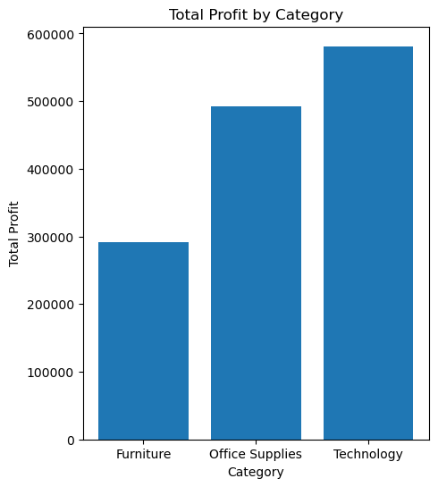

```python
category_profit = data.groupby('Category')['Profit'].sum().reset_index()

plt.figure(figsize=(5, 6))
plt.bar(category_profit['Category'], category_profit['Profit'])
plt.xlabel('Category')
plt.ylabel('Total Profit')
plt.title('Total Profit by Category')
plt.show()
```

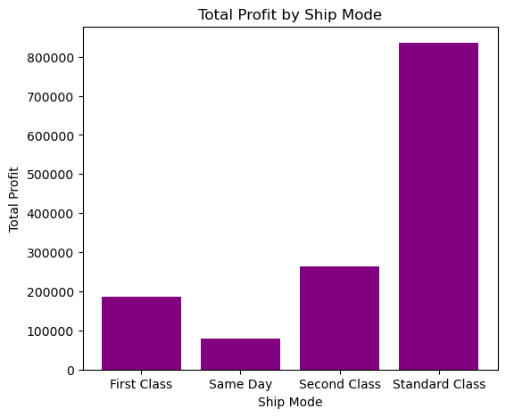

```python
profit_by_ship_mode = data.groupby('Ship Mode')['Profit'].sum().reset_index()
plt.figure(figsize=(6, 5))
plt.bar(profit_by_ship_mode['Ship Mode'], profit_by_ship_mode['Profit'], color='purple')
plt.xlabel('Ship Mode')
plt.ylabel('Total Profit')
plt.title('Total Profit by Ship Mode')
plt.show()
```

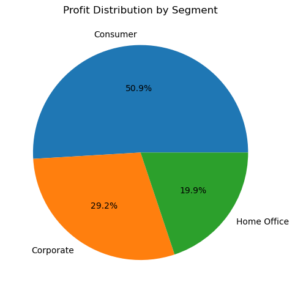

```python
profit_by_segment = data.groupby('Segment')['Profit'].sum().reset_index()
plt.figure(figsize=(5, 6))
plt.pie(profit_by_segment['Profit'], labels=profit_by_segment['Segment'], autopct='%1.1f%%')
plt.title('Profit Distribution by Segment')
plt.tight_layout()
plt.show()
```

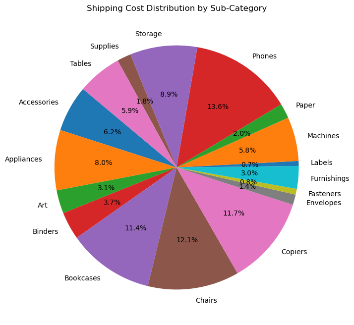

```python
sub_category_shipping_cost = data.groupby('Sub-Category')['Shipping Cost'].sum()
plt.figure(figsize=(8, 8))
plt.pie(sub_category_shipping_cost, labels=sub_category_shipping_cost.index, autopct='%1.1f%%', startangle=140)
plt.title('Shipping Cost Distribution by Sub-Category')
plt.show()
```

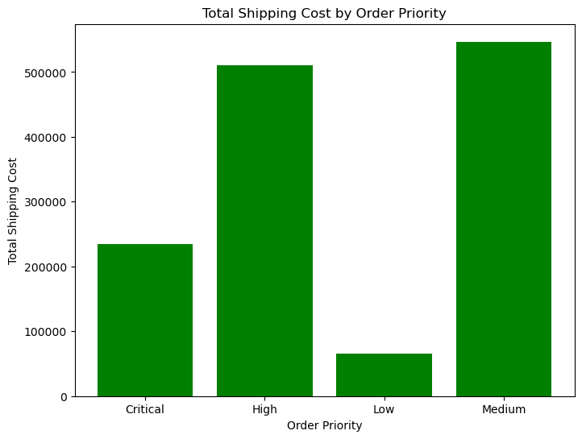

```python
order_priority_shipping_cost = data.groupby('Order Priority')['Shipping Cost'].sum().reset_index()
plt.figure(figsize=(8, 6))
plt.bar(order_priority_shipping_cost['Order Priority'], order_priority_shipping_cost['Shipping Cost'], color='green')
plt.xlabel('Order Priority')
plt.ylabel('Total Shipping Cost')
plt.title('Total Shipping Cost by Order Priority')
plt.show()
```

# Summary

**Number of Orders per Region:**

- The data includes the number of orders in various regions, with Western Europe having the highest number of orders (5883), followed by Central America (5616), and Oceania (3487).

**Average Profit per Category:**

- The data shows the average profit per category, with Technology having the highest average profit (57.31), followed by Furniture (29.59), and Office Supplies (15.74).

**Total Quantity Sold:**

- The total quantity of products sold across all categories is 178312.

**Most Common Product Category:**

- The most common product category is Office Supplies.

**Average Shipping Cost:**

- The average shipping cost for all orders is approximately 26.48.

**Total Profit:**

- The total profit from all orders is 1365289.06.

**Average Shipping Cost by Market and Region:**

- The data provides the average shipping cost based on different markets and regions. For example, in the Africa market, the Central Africa region has an average shipping cost of 25.49, while in the Asia Pacific market, Eastern Asia has an average shipping cost of 40.37.

**Count of Unique Values in Categorical Columns:**

- The data includes the count of unique values for various categorical columns, such as Order ID, Day, Ship Mode, Customer ID, etc.